# 02_Data_transformation

Arthur M. Albuquerque

May 10, 2021

If you are not interested in the code, you can select the “Hide all code” option on the upper-right corner.

Load data generated in the “01_Data_overview.Rmd” file.

```r
d = read.csv((here("final_analyses", "output", "data", # file path
                   "respiratory-data.csv")),           # file name
             header = T)
d = d %>%
  as_tibble() %>%
  select(!starts_with("X")) %>%

  # To create columns with the difference between sample size and events per arm
  # This will be useful while using Beta distributions,
  # diff = the Beta (b) parameter in a Beta distribution (a,b)
  mutate(diff_toci = total_toci - events_toci,
         diff_control = total_control - events_control)
```

Filter data to create different objects.

```r
### To create separate objects per subgroup
# Here I rename columns so these variables are usable in my beta_fun()

# Isolating RECOVERY
recovery_simple_oxygen =
  d %>%
  filter(trial == "RECOVERY",
         oxygen == "simple oxygen") %>%

  # Only RECOVERY, so there is no need to sum, just to rename the columns
  rename(sum_events_toci = "events_toci",
         sum_total_toci = "total_toci",
         sum_diff_toci = "diff_toci",
         sum_events_control = "events_control",
         sum_total_control = "total_control",
         sum_diff_control = "diff_control")

recovery_non_invasive =
  d %>%
  filter(trial == "RECOVERY",
         oxygen == "non-invasive ventilation") %>%

  # Only RECOVERY, so there is no need to sum, just to rename the columns
  rename(sum_events_toci = "events_toci",
         sum_total_toci = "total_toci",
         sum_diff_toci = "diff_toci",
         sum_events_control = "events_control",
         sum_total_control = "total_control",
         sum_diff_control = "diff_control")

recovery_invasive =
  d %>%
  filter(trial == "RECOVERY",
         oxygen == "invasive ventilation") %>%

  # Only RECOVERY, so there is no need to sum, just to rename the columns
  rename(sum_events_toci = "events_toci",
         sum_total_toci = "total_toci",
         sum_diff_toci = "diff_toci",
         sum_events_control = "events_control",
         sum_total_control = "total_control",
         sum_diff_control = "diff_control")

## Group all other trials per outcome and sum the events/sample size

trials_simple_oxygen =
  d %>%
  filter(trial != "RECOVERY",
         oxygen == "simple oxygen") %>%

  # Only COVACTA, so no need to sum, just to rename the columns
  rename(sum_events_toci = "events_toci",
         sum_total_toci = "total_toci",
         sum_diff_toci = "diff_toci",
         sum_events_control = "events_control",
         sum_total_control = "total_control",
         sum_diff_control = "diff_control")

trials_non_invasive =
  d %>%
  filter(trial != "RECOVERY",
         oxygen == "non-invasive ventilation") %>%
  group_by(outcome) %>%
  summarise(sum_events_toci = sum(events_toci),
            sum_total_toci = sum(total_toci),
            sum_diff_toci = sum(diff_toci),
            sum_events_control = sum(events_control),
            sum_total_control = sum(total_control),
            sum_diff_control = sum(diff_control))

trials_invasive =
  d %>%
  filter(trial != "RECOVERY",
         oxygen == "invasive ventilation") %>%
  group_by(outcome) %>%
  summarise(sum_events_toci = sum(events_toci),
            sum_total_toci = sum(total_toci),
            sum_diff_toci = sum(diff_toci),
            sum_events_control = sum(events_control),
            sum_total_control = sum(total_control),
            sum_diff_control = sum(diff_control))
```

# Mortality outcome

## Non-informative priors

```r
### Generate posterior beta distributions using a noninformative beta(1,1) prior

set.seed = 123 # set seed for reproducibility (rbeta() function)

# Here I use the noninformative_posterior() that you can find in the
# following path:
# here("final_analyses", "script", "functions", "noninformative_posterior.R")

noninformative_recovery_simple_oxygen_death = noninformative_posterior(
  recovery_simple_oxygen, # data
  "mortality" # outcome
)

noninformative_recovery_non_invasive_death = noninformative_posterior(
  recovery_non_invasive, # data
  "mortality" # outcome
)

noninformative_recovery_invasive_death = noninformative_posterior(
  recovery_invasive, # data
  "mortality" # outcome
)
```

### Simple oxygen only subgroup

```r
tibble(
  rows = dim(noninformative_recovery_simple_oxygen_death)[1],
  columns = dim(noninformative_recovery_simple_oxygen_death)[2]
  ) %>%
  flextable()
```

| rows | columns |
| --- | --- |
| 100,000 | 2 |

```r
head(noninformative_recovery_simple_oxygen_death) %>% flextable()
```

| control | toci |
| --- | --- |
| 0.2341900 | 0.1703958 |
| 0.2261098 | 0.1870612 |
| 0.2433289 | 0.2025973 |
| 0.2030512 | 0.1781620 |
| 0.2156659 | 0.1818614 |
| 0.2207328 | 0.2031185 |

### Non-invasive ventilation subgroup

```r
tibble(
  rows = dim(noninformative_recovery_non_invasive_death)[1],
  columns = dim(noninformative_recovery_non_invasive_death)[2]
  ) %>%
  flextable()
```

| rows | columns |
| --- | --- |
| 100,000 | 2 |

```r
head(noninformative_recovery_non_invasive_death) %>% flextable()
```

| control | toci |
| --- | --- |
| 0.4144325 | 0.4029595 |
| 0.4284683 | 0.3783633 |
| 0.4501832 | 0.3476671 |
| 0.4212211 | 0.3779025 |
| 0.3995041 | 0.3463257 |
| 0.4365311 | 0.3753672 |

### Invasive mechanical ventilation subgroup

```r
tibble(
  rows = dim(noninformative_recovery_invasive_death)[1],
  columns = dim(noninformative_recovery_invasive_death)[2]
  ) %>%
  flextable()
```

| rows | columns |
| --- | --- |
| 100,000 | 2 |

```r
head(noninformative_recovery_invasive_death) %>% flextable()
```

| control | toci |
| --- | --- |
| 0.5064279 | 0.4932511 |
| 0.5132106 | 0.4680885 |
| 0.5030813 | 0.4933442 |
| 0.5205614 | 0.4729926 |
| 0.5561179 | 0.5567056 |
| 0.4953537 | 0.5232583 |

```r
# Save objects with posterior distributions using non-informative priors

# save(noninformative_recovery_simple_oxygen_death,
#      noninformative_recovery_non_invasive_death,
#      noninformative_recovery_invasive_death,
#
#      file = here("final_analyses", "output", "data",
#                  "noninformative_recovery_death.RData"))
```

## Evidence-based priors

### Simple oxygen only subgroup

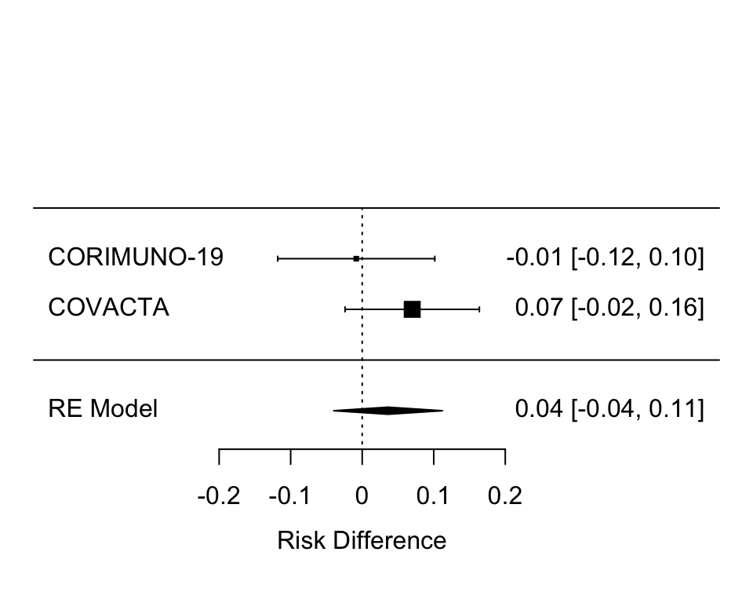

```r
priors_simple_oxygen_raw =
  d %>%
  filter(
    trial != "RECOVERY",
    oxygen == "simple oxygen"
  )

priors_simple_oxygen_death =
  rma(
    # Outcome
    measure = "RD", # risk difference

    # Tocilizumab group
    ai = events_toci,
    n1i = total_toci,

    # Control group
    ci = events_control,
    n2i = total_control,

    data = priors_simple_oxygen_raw %>% filter(outcome == "mortality"),

    slab = paste(trial),
    method = "REML"
  )

# Visualize it
forest(priors_simple_oxygen_death)
```

```r
recovery_simple_oxygen_normal_death %>% flextable()
```

| data.mean | data.sd | prior.mean | prior.sd | post.mean | post.sd |
| --- | --- | --- | --- | --- | --- |
| -0.03685426 | 0.01885019 | 0.03620342 | 0.03873858 | -0.02286748 | 0.01695 |

### Non-invasive ventilation subgroup

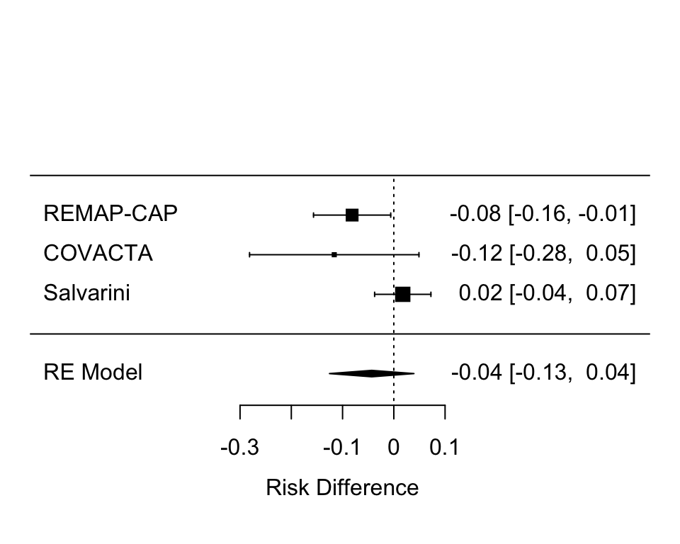

```r
priors_noninvasive_raw =
  d %>%
  filter(
    trial != "RECOVERY",
    oxygen == "non-invasive ventilation"
  )

priors_noninvasive_death =
  rma(
    # Outcome
    measure = "RD", # risk difference

    # Tocilizumab group
    ai = events_toci,
    n1i = total_toci,

    # Control group
    ci = events_control,
    n2i = total_control,

    data = priors_noninvasive_raw %>% filter(outcome == "mortality"),

    slab = paste(trial),
    method = "REML"
  )

forest(priors_noninvasive_death)
```

```r
recovery_noninvasive_normal_death %>% flextable()
```

| data.mean | data.sd | prior.mean | prior.sd | post.mean | post.sd |
| --- | --- | --- | --- | --- | --- |
| -0.04363495 | 0.02383094 | -0.04314171 | 0.04202758 | -0.04351495 | 0.02073021 |

### Invasive mechanical ventilation subgroup

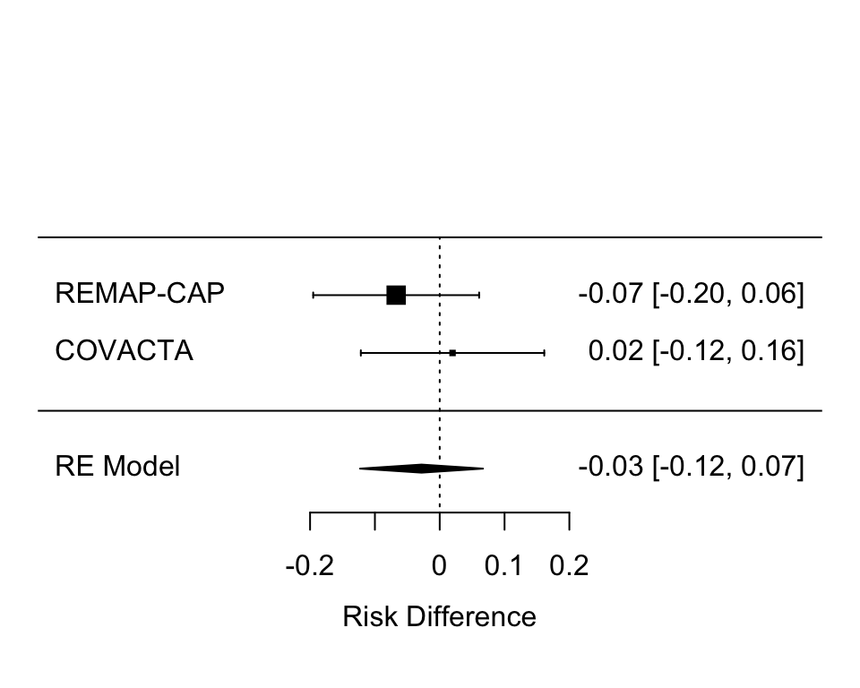

```r
priors_invasive_raw =
  d %>%
  filter(
    trial != "RECOVERY",
    oxygen == "invasive ventilation"
  )

priors_invasive_death =
  rma(
    # Outcome
    measure = "RD", # risk difference

    # Tocilizumab group
    ai = events_toci,
    n1i = total_toci,

    # Control group
    ci = events_control,
    n2i = total_control,

    data = priors_invasive_raw %>% filter(outcome == "mortality"),

    slab = paste(trial),
    method = "REML"
  )

forest(priors_invasive_death)
```

```r
recovery_invasive_normal_death %>% flextable()
```

| data.mean | data.sd | prior.mean | prior.sd | post.mean | post.sd |
| --- | --- | --- | --- | --- | --- |
| -0.01799675 | 0.04214502 | -0.02805463 | 0.04842942 | -0.02233118 | 0.03179231 |

```r
## Save objects with rma() outputs to show forest plot in other files

# save(priors_simple_oxygen_death,
#      priors_noninvasive_death,
#      priors_invasive_death,
#
#      file = here("final_analyses", "output", "data",
#                  "priors_death.RData"))
```

## Alternative priors

### Simple oxygen subgroup

```r
multiple_priors_simple_oxygen_death %>% flextable() %>% autofit()
```

| type | data.mean | data.sd | prior.mean | prior.sd | post.mean | post.sd |
| --- | --- | --- | --- | --- | --- | --- |
| evidence-based | -0.03685426 | 0.01885019 | 0.03620342 | 0.03873858 | -0.02286748 | 0.01695 |
| skeptical | -0.03685426 | 0.01885019 | 0.00000000 | 0.03873858 | -0.02979857 | 0.01695 |
| optimistic | -0.03685426 | 0.01885019 | -0.05000000 | 0.03873858 | -0.03937099 | 0.01695 |
| pessimistic | -0.03685426 | 0.01885019 | 0.05000000 | 0.03873858 | -0.02022615 | 0.01695 |

### Non-invasive ventilation subgroup

```r
multiple_priors_noninvasive_death %>% flextable() %>% autofit()
```

| type | data.mean | data.sd | prior.mean | prior.sd | post.mean | post.sd |
| --- | --- | --- | --- | --- | --- | --- |
| evidence-based | -0.04363495 | 0.02383094 | -0.04314171 | 0.04202758 | -0.04351495 | 0.02073021 |
| skeptical | -0.04363495 | 0.02383094 | 0.00000000 | 0.04202758 | -0.03301866 | 0.02073021 |
| optimistic | -0.04363495 | 0.02383094 | -0.05000000 | 0.04202758 | -0.04518355 | 0.02073021 |
| pessimistic | -0.04363495 | 0.02383094 | 0.05000000 | 0.04202758 | -0.02085376 | 0.02073021 |

### Invasive mechanical ventilation subgroup

```r
multiple_priors_invasive_death %>% flextable() %>% autofit()
```

| type | data.mean | data.sd | prior.mean | prior.sd | post.mean | post.sd |
| --- | --- | --- | --- | --- | --- | --- |
| evidence-based | -0.01799675 | 0.04214502 | -0.02805463 | 0.04842942 | -0.02233118 | 0.03179231 |
| skeptical | -0.01799675 | 0.04214502 | 0.00000000 | 0.04842942 | -0.01024108 | 0.03179231 |
| optimistic | -0.01799675 | 0.04214502 | -0.05000000 | 0.04842942 | -0.03178851 | 0.03179231 |
| pessimistic | -0.01799675 | 0.04214502 | 0.05000000 | 0.04842942 | 0.01130636 | 0.03179231 |

## Compiling all posteriors

```r
### Compile noninformative prior + other priors into a tibble for summary plot

## Simple oxygen
all_posteriors_simple_oxygen_death = tibble_all_posteriors(

  # Output from noninformative_posterior()
  noninformative_recovery_simple_oxygen_death,

  # Output from normal_approximation_multiple_priors()
  multiple_priors_simple_oxygen_death
)

## Non-invasive ventilation
all_posteriors_noninvasive_death = tibble_all_posteriors(

  # Output from noninformative_posterior()
  noninformative_recovery_non_invasive_death,

  # Output from normal_approximation_multiple_priors()
  multiple_priors_noninvasive_death
)

## Invasive mechanical ventilation
all_posteriors_invasive_death = tibble_all_posteriors(

  # Output from noninformative_posterior()
  noninformative_recovery_invasive_death,

  # Output from normal_approximation_multiple_priors()
  multiple_priors_invasive_death
)
```

Example of one output with all the posteriors

```r
head(all_posteriors_simple_oxygen_death)%>% flextable() %>% autofit()
```

| Non-informative | Evidence-based | Skeptical | Optimistic | Pessimistic |
| --- | --- | --- | --- | --- |
| -0.06379416 | -0.01365711 | -0.025198709 | -0.04348677 | -0.007055536 |
| -0.03904864 | -0.01523255 | -0.007906744 | -0.05048967 | -0.045012518 |
| -0.04073163 | -0.01949355 | -0.023415397 | -0.04430801 | 0.005235559 |
| -0.02488916 | -0.02732405 | -0.039876416 | -0.04798873 | -0.029559156 |
| -0.03380447 | -0.03828745 | -0.059547234 | -0.03156016 | -0.017664814 |
| -0.01761432 | -0.00317727 | -0.042652922 | -0.03494724 | -0.028918749 |

```r
## Save objects with mean + SD of multiple priors along with
## RECOVERY data and posterior distributions

# save(multiple_priors_simple_oxygen_death,
#      multiple_priors_noninvasive_death,
#      multiple_priors_invasive_death,
#
#      file = here("final_analyses", "output", "data",
#                  "multiple_priors_death.RData"))
```

```r
## Save objects with all posteriors

# save(all_posteriors_simple_oxygen_death,
#      all_posteriors_noninvasive_death,
#      all_posteriors_invasive_death,
#
#      file = here("final_analyses", "output", "data",
#                  "all_posteriors_death.RData"))
```

# Hospital discharge outome

## Non-informative priors

```r
### Generate posterior beta distributions using a noninformative beta(1,1) prior

set.seed = 123 # set seed for reproducibility (rbeta() function)

# Here I use the noninformative_posterior() that you can find in the
# following path:
# here("final_analyses", "script", "functions", "noninformative_posterior.R")

noninformative_recovery_simple_oxygen_discharge = noninformative_posterior(
  recovery_simple_oxygen, # data
  "discharge" # outcome
)

noninformative_recovery_non_invasive_discharge = noninformative_posterior(
  recovery_non_invasive, # data
  "discharge" # outcome
)

noninformative_recovery_invasive_discharge = noninformative_posterior(
  recovery_invasive, # data
  "discharge" # outcome
)
```

### Simple oxygen only subgroup

```r
tibble(
  rows = dim(noninformative_recovery_simple_oxygen_discharge)[1],
  columns = dim(noninformative_recovery_simple_oxygen_discharge)[2]
  ) %>%
  flextable()
```

| rows | columns |
| --- | --- |
| 100,000 | 2 |

```r
head(noninformative_recovery_simple_oxygen_discharge) %>% flextable()
```

| control | toci |
| --- | --- |
| 0.6767653 | 0.7450963 |
| 0.6672023 | 0.7421109 |
| 0.6780114 | 0.7495511 |
| 0.6607162 | 0.7807094 |
| 0.6908034 | 0.7401120 |
| 0.6862514 | 0.7561622 |

### Non-invasive ventilation subgroup

```r
tibble(
  rows = dim(noninformative_recovery_non_invasive_discharge)[1],
  columns = dim(noninformative_recovery_non_invasive_discharge)[2]
  ) %>%
  flextable()
```

| rows | columns |
| --- | --- |
| 100,000 | 2 |

```r
head(noninformative_recovery_non_invasive_discharge) %>% flextable()
```

| control | toci |
| --- | --- |
| 0.4114666 | 0.5172584 |
| 0.4074955 | 0.4921089 |
| 0.4366981 | 0.4919465 |
| 0.4220780 | 0.4842885 |
| 0.4221913 | 0.4887771 |
| 0.4170385 | 0.4823535 |

### Invasive mechanical ventilation subgroup

```r
tibble(
  rows = dim(noninformative_recovery_invasive_discharge)[1],
  columns = dim(noninformative_recovery_invasive_discharge)[2]
  ) %>%
  flextable()
```

| rows | columns |
| --- | --- |
| 100,000 | 2 |

```r
head(noninformative_recovery_invasive_discharge) %>% flextable()
```

| control | toci |
| --- | --- |
| 0.1454165 | 0.2003673 |
| 0.1911939 | 0.1424514 |
| 0.1891646 | 0.2003796 |
| 0.1796255 | 0.2111473 |
| 0.1604335 | 0.2140767 |
| 0.1873870 | 0.2194367 |

```r
# Save objects for the posterior using non-informative priors

# save(noninformative_recovery_simple_oxygen_discharge,
#      noninformative_recovery_non_invasive_discharge,
#      noninformative_recovery_invasive_discharge,
#
#      file = here("final_analyses", "output", "data",
#                  "noninformative_recovery_discharge.RData"))
```

## Evidence-based priors

### Simple oxygen only subgroup

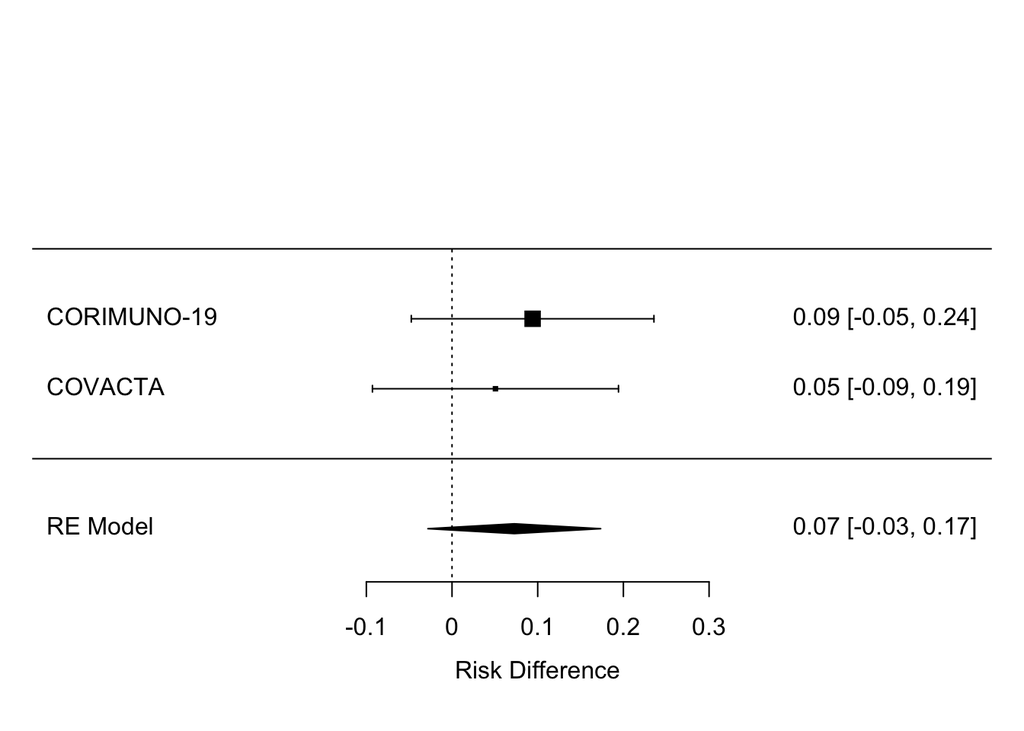

```r
priors_simple_oxygen_raw =
  d %>%
  filter(
    trial != "RECOVERY",
    oxygen == "simple oxygen"
  )

priors_simple_oxygen_discharge =
  rma(
    # Outcome
    measure = "RD", # risk difference

    # Tocilizumab group
    ai = events_toci,
    n1i = total_toci,

    # Control group
    ci = events_control,
    n2i = total_control,

    data = priors_simple_oxygen_raw %>% filter(outcome == "discharge"),

    slab = paste(trial),
    method = "REML"
  )

forest(priors_simple_oxygen_discharge)
```

```r
recovery_simple_oxygen_normal_discharge %>% flextable()
```

| data.mean | data.sd | prior.mean | prior.sd | post.mean | post.sd |
| --- | --- | --- | --- | --- | --- |
| 0.06485433 | 0.02086795 | 0.07267681 | 0.05144147 | 0.06595972 | 0.01933741 |

### Non-invasive ventilation subgroup

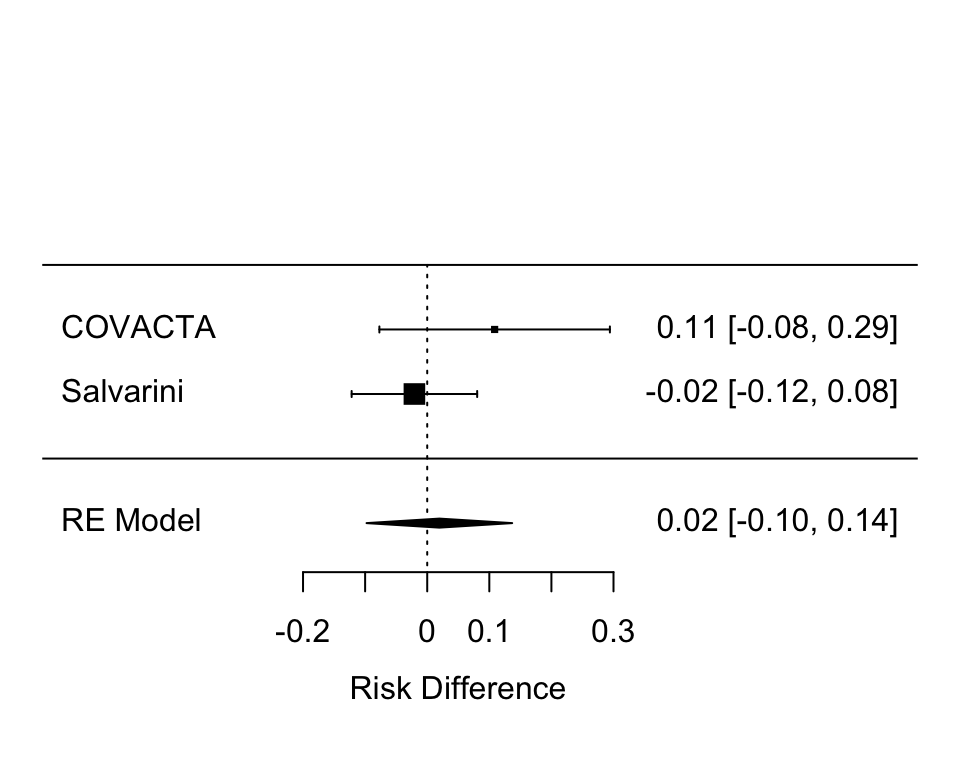

```r
priors_noninvasive_raw =
  d %>%
  filter(
    trial != "RECOVERY",
    oxygen == "non-invasive ventilation"
  )

priors_noninvasive_discharge =
  rma(
    # Outcome
    measure = "RD", # risk difference

    # Tocilizumab group
    ai = events_toci,
    n1i = total_toci,

    # Control group
    ci = events_control,
    n2i = total_control,

    data = priors_noninvasive_raw %>% filter(outcome == "discharge"),

    slab = paste(trial),
    method = "REML"
  )

forest(priors_noninvasive_discharge)
```

```r
recovery_noninvasive_normal_discharge %>% flextable()
```

| data.mean | data.sd | prior.mean | prior.sd | post.mean | post.sd |
| --- | --- | --- | --- | --- | --- |
| 0.07208977 | 0.02418532 | 0.01955218 | 0.05980949 | 0.06470629 | 0.02242154 |

### Invasive mechanical ventilation subgroup

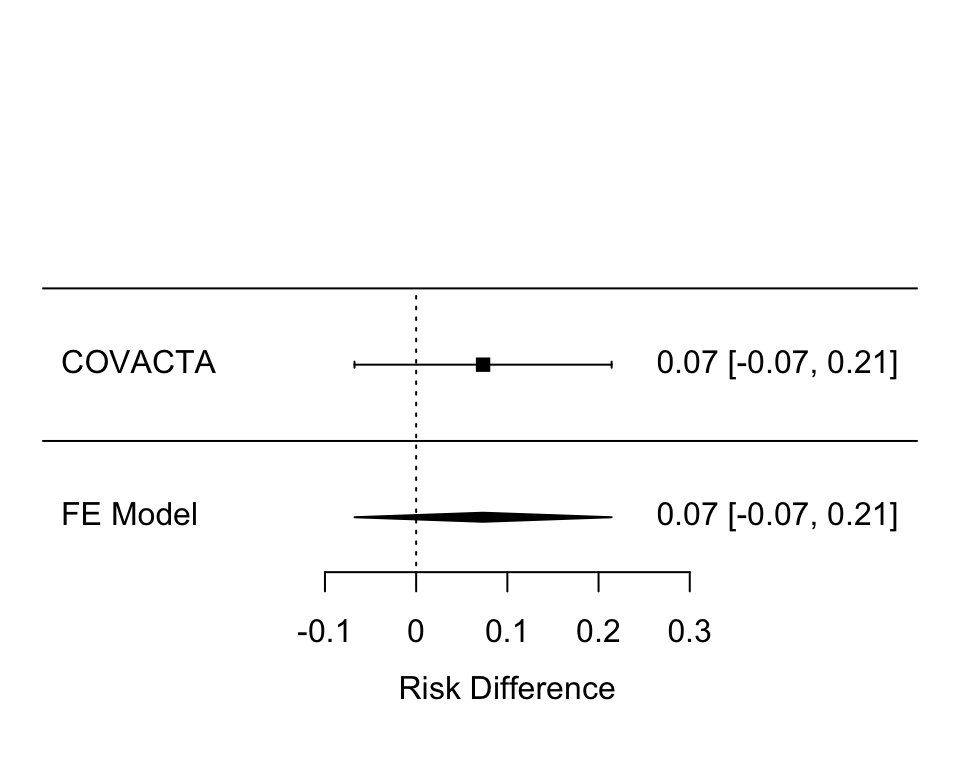

```r
priors_invasive_raw =
  d %>%
  filter(
    trial != "RECOVERY",
    oxygen == "invasive ventilation"
  )

priors_invasive_discharge =
  rma(
    # Outcome
    measure = "RD", # risk difference

    # Tocilizumab group
    ai = events_toci,
    n1i = total_toci,

    # Control group
    ci = events_control,
    n2i = total_control,

    data = priors_invasive_raw %>% filter(outcome == "discharge"),

    slab = paste(trial),
    method = "REML"
  )

forest(priors_invasive_discharge)
```

```r
recovery_invasive_normal_discharge %>% flextable()
```

| data.mean | data.sd | prior.mean | prior.sd | post.mean | post.sd |
| --- | --- | --- | --- | --- | --- |
| 0.03416591 | 0.03219668 | 0.07337088 | 0.07192892 | 0.04070992 | 0.02938698 |

```r
## Save objects with rma() outputs to show forest plot in other files

# save(priors_simple_oxygen_discharge,
#      priors_noninvasive_discharge,
#      priors_invasive_discharge,
#
#      file = here("final_analyses", "output", "data",
#                  "priors_discharge.RData"))
```

## Alternative priors

### Simple oxygen subgroup

```r
multiple_priors_simple_oxygen_discharge %>% flextable() %>% autofit()
```

| type | data.mean | data.sd | prior.mean | prior.sd | post.mean | post.sd |
| --- | --- | --- | --- | --- | --- | --- |
| evidence-based | 0.06485433 | 0.02086795 | 0.07267681 | 0.05144147 | 0.06595972 | 0.01933741 |
| skeptical | 0.06485433 | 0.02086795 | 0.00000000 | 0.05144147 | 0.05568983 | 0.01933741 |
| optimistic | 0.06485433 | 0.02086795 | 0.05000000 | 0.05144147 | 0.06275528 | 0.01933741 |
| pessimistic | 0.06485433 | 0.02086795 | -0.05000000 | 0.05144147 | 0.04862438 | 0.01933741 |

### Non-invasive ventilation subgroup

```r
multiple_priors_noninvasive_discharge %>% flextable() %>% autofit()
```

| type | data.mean | data.sd | prior.mean | prior.sd | post.mean | post.sd |
| --- | --- | --- | --- | --- | --- | --- |
| evidence-based | 0.07208977 | 0.02418532 | 0.01955218 | 0.05980949 | 0.06470629 | 0.02242154 |
| skeptical | 0.07208977 | 0.02418532 | 0.00000000 | 0.05980949 | 0.06195849 | 0.02242154 |
| optimistic | 0.07208977 | 0.02418532 | 0.05000000 | 0.05980949 | 0.06898534 | 0.02242154 |
| pessimistic | 0.07208977 | 0.02418532 | -0.05000000 | 0.05980949 | 0.05493164 | 0.02242154 |

### Invasive mechanical ventilation subgroup

```r
multiple_priors_invasive_discharge %>% flextable() %>% autofit()
```

| type | data.mean | data.sd | prior.mean | prior.sd | post.mean | post.sd |
| --- | --- | --- | --- | --- | --- | --- |
| evidence-based | 0.03416591 | 0.03219668 | 0.07337088 | 0.07192892 | 0.04070992 | 0.02938698 |
| skeptical | 0.03416591 | 0.03219668 | 0.00000000 | 0.07192892 | 0.02846300 | 0.02938698 |
| optimistic | 0.03416591 | 0.03219668 | 0.05000000 | 0.07192892 | 0.03680890 | 0.02938698 |
| pessimistic | 0.03416591 | 0.03219668 | -0.05000000 | 0.07192892 | 0.02011711 | 0.02938698 |

## Compiling all posteriors

```r
### Compile noninformative prior + other priors into a tibble for summary plot

## Simple oxygen
all_posteriors_simple_oxygen_discharge = tibble_all_posteriors(

  # Output from noninformative_posterior()
  noninformative_recovery_simple_oxygen_discharge,

  # Output from normal_approximation_multiple_priors()
  multiple_priors_simple_oxygen_discharge
)

## Non-invasive ventilation
all_posteriors_noninvasive_discharge = tibble_all_posteriors(

  # Output from noninformative_posterior()
  noninformative_recovery_non_invasive_discharge,

  # Output from normal_approximation_multiple_priors()
  multiple_priors_noninvasive_discharge
)

## Invasive mechanical ventilation
all_posteriors_invasive_discharge = tibble_all_posteriors(

  # Output from noninformative_posterior()
  noninformative_recovery_invasive_discharge,

  # Output from normal_approximation_multiple_priors()
  multiple_priors_invasive_discharge
)
```

Example of one output with all the posteriors

```r
head(all_posteriors_simple_oxygen_discharge) %>% flextable() %>% autofit()
```

| Non-informative | Evidence-based | Skeptical | Optimistic | Pessimistic |
| --- | --- | --- | --- | --- |
| 0.06833099 | 0.05573398 | 0.05579845 | 0.06800913 | 0.059979438 |
| 0.07490865 | 0.06601245 | 0.03907335 | 0.04991653 | 0.003772746 |
| 0.07153973 | 0.03701688 | 0.09677612 | 0.03466504 | 0.028595268 |
| 0.11999320 | 0.07817021 | 0.05632039 | 0.07085035 | 0.019029026 |
| 0.04930860 | 0.07393143 | 0.06182353 | 0.04289300 | 0.018769213 |
| 0.06991082 | 0.05274200 | 0.06764060 | 0.05958950 | 0.043437649 |

```r
## Save objects with mean + SD of multiple priors along with
## RECOVERY data and posterior distributions

# save(multiple_priors_simple_oxygen_discharge,
#      multiple_priors_noninvasive_discharge,
#      multiple_priors_invasive_discharge,
#
#      file = here("final_analyses", "output", "data",
#                  "multiple_priors_discharge.RData"))
```

```r
## Save objects with all posteriors

# save(all_posteriors_simple_oxygen_discharge,
#      all_posteriors_noninvasive_discharge,
#      all_posteriors_invasive_discharge,
#
#      file = here("final_analyses", "output", "data",
#                  "all_posteriors_discharge.RData"))
```

# Corticosteroid subgroups

Let’s check how much data we have

```r
d %>%
  filter(corticosteroids == 1) %>%
  group_by(trial, outcome) %>%
  count() %>%
  select(-n) %>%
  flextable() %>%
  autofit()
```

| trial | outcome |
| --- | --- |
| COVACTA | discharge |
| COVACTA | mortality |
| RECOVERY | discharge |
| RECOVERY | mortality |
| REMAP-CAP | mortality |

```r
d %>%
  group_by(trial, outcome) %>%
  summarise("total number of patients" = sum(total_control + total_toci)) %>%
  flextable() %>%
  autofit()
```

| trial | outcome | total number of patients |
| --- | --- | --- |
| COVACTA | discharge | 438 |
| COVACTA | mortality | 438 |
| RECOVERY | discharge | 4,109 |
| RECOVERY | mortality | 4,109 |
| REMAP-CAP | mortality | 792 |

## REMAP-CAP

Regarding this trial, we extracted data on corticosteroid subgroups from Figure 9 in their appendix. Unfortunately, the authors don’t provide raw number of events in each subgroup. Thus, I used the [{juicr} package](https://cran.r-project.org/web/packages/juicr/index.html) to extract data directly from Figure 9. The raw data and extraction report generated by {juicr} can be found in the “final_analyses/data” folder in my [GitHub](https://github.com/arthur-albuquerque/tocilizumab_reanalysis).

Of note, REMAP-CAP is a three-arm randomized controlled trial that tested tocilizumab and sarilumab (both are IL-6 antagonist) vs. usual care. The authors only provided pooled data from these IL-6 antagonists vs. usual care in Figure 9. Thus, we decided to analyze data on corticosteroid subgroups from REMAP-CAP with different weights: 100%, 75%, 50%, and 0%. In this way, the numbers of events and sample sizes are multiplied by 1, 0.75, 0.5, or 0, respectively. These different weights will directly reflect on the variance of the prior distribution, increasing its uncertainty.

Here are the original (100% weight) number of events and sample sizes from the REMAP-CAP trial:

```r
d %>%
  filter(trial == "REMAP-CAP") %>%
  select(trial:total_control) %>%
  flextable() %>%
  autofit()
```

| trial | outcome | corticosteroids | events_toci | total_toci | events_control | total_control |
| --- | --- | --- | --- | --- | --- | --- |
| REMAP-CAP | mortality | 1 | 102 | 358 | 134 | 361 |
| REMAP-CAP | mortality | 0 | 6 | 37 | 9 | 36 |

Now with 75% weight:

```r
# Create custom function
multiply75 = function(x){x*0.75}

remap75 = d %>%
  filter(trial == "REMAP-CAP") %>%
  # Multiply columns regarding events and sample size using custom function
  mutate(across(events_toci:total_control, ~ multiply75(.))) %>%
  # Re-calculate "diff" columns with 75% weight data
  mutate(diff_toci = total_toci - events_toci,
         diff_control = total_control - events_control) %>%
  # Change name of the trial
  mutate(trial = "75% REMAP-CAP")

remap75 %>%
  flextable() %>%
  autofit()
```

| trial | outcome | corticosteroids | events_toci | total_toci | events_control | total_control | diff_toci | diff_control |
| --- | --- | --- | --- | --- | --- | --- | --- | --- |
| 75% REMAP-CAP | mortality | 1 | 76.5 | 268.50 | 100.50 | 270.75 | 192.00 | 170.25 |
| 75% REMAP-CAP | mortality | 0 | 4.5 | 27.75 | 6.75 | 27.00 | 23.25 | 20.25 |

Now with 50% weight:

```r
# Create custom function
multiply50 = function(x){x*0.50}

remap50 = d %>%
  filter(trial == "REMAP-CAP") %>%
  # Multiply columns regarding events and sample size using custom function
  mutate(across(events_toci:total_control, ~ multiply50(.))) %>%
  # Re-calculate "diff" columns with 50% weight data
  mutate(diff_toci = total_toci - events_toci,
         diff_control = total_control - events_control) %>%
  # Change name of the trial
  mutate(trial = "50% REMAP-CAP")

remap50 %>%
  flextable() %>%
  autofit()
```

| trial | outcome | corticosteroids | events_toci | total_toci | events_control | total_control | diff_toci | diff_control |
| --- | --- | --- | --- | --- | --- | --- | --- | --- |
| 50% REMAP-CAP | mortality | 1 | 51 | 179.0 | 67.0 | 180.5 | 128.0 | 113.5 |
| 50% REMAP-CAP | mortality | 0 | 3 | 18.5 | 4.5 | 18.0 | 15.5 | 13.5 |

0% weight means that data from the REMAP-CAP trial wouldn’t be used in the analysis:

```r
# Create custom function
multiply0 = function(x){x*0}

remap0 = d %>%
  filter(trial == "REMAP-CAP") %>%
  # Multiply columns regarding events and sample size using custom function
  mutate(across(events_toci:total_control, ~ multiply0(.))) %>%
  # Re-calculate "diff" columns with 0% weight data
  mutate(diff_toci = total_toci - events_toci,
         diff_control = total_control - events_control) %>%
  # Change name of the trial
  mutate(trial = "0% REMAP-CAP")

remap0 %>%
  flextable() %>%
  autofit()
```

| trial | outcome | corticosteroids | events_toci | total_toci | events_control | total_control | diff_toci | diff_control |
| --- | --- | --- | --- | --- | --- | --- | --- | --- |
| 0% REMAP-CAP | mortality | 1 | 0 | 0 | 0 | 0 | 0 | 0 |
| 0% REMAP-CAP | mortality | 0 | 0 | 0 | 0 | 0 | 0 | 0 |

Now let’s add this data as new rows in our data frame:

```r
d = d %>%
  bind_rows(remap75, remap50)

d %>%
  distinct(trial) %>%
  flextable() %>%
  autofit()
```

| trial |
| --- |
| COVACTA |
| RECOVERY |
| REMAP-CAP |
| 75% REMAP-CAP |
| 50% REMAP-CAP |

## Mortality outcome

### Using REMAP-CAP with 100% weight

#### Using corticosteroids

Let’s start the data wrangling

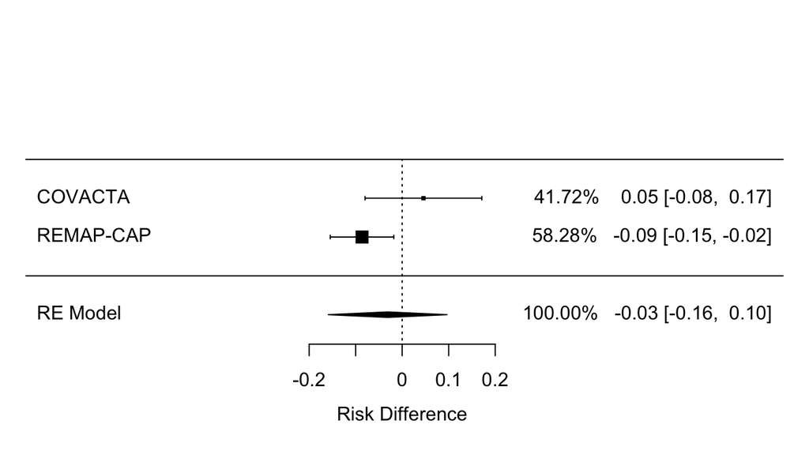

```r
priors_100_using_cortico_data_death =
  d %>%
  # Remove rows using different weights on REMAP-CAP
  filter(str_detect(trial, "%", negate = TRUE)) %>%
  filter(
    trial != "RECOVERY", # Not RECOVERY
    corticosteroids == 1 # Using corticosteroids
  )

priors_100_using_cortico_death =
  rma(
    # Outcome
    measure = "RD", # risk difference

    # Tocilizumab group
    ai = events_toci,
    n1i = total_toci,

    # Control group
    ci = events_control,
    n2i = total_control,

    data = priors_100_using_cortico_data_death %>% filter(outcome == "mortality"),

    slab = paste(trial),
    method = "REML"
  )

forest(priors_100_using_cortico_death,
       showweights = T,
       refline     = 0)
```

```r
## Save objects with rma() outputs to show forest plot in other files

# save(priors_100_using_cortico_death,
#
#      file = here("final_analyses", "output", "data",
#                  "priors_100_using_cortico_death.RData"))
```

```r
### Generate posterior beta distributions using a noninformative beta(1,1) prior

set.seed = 123 # set seed for reproducibility (rbeta() function)

# Here I use the uninformative_posterior_beta() in which you can find in the
# following path:
# here("final_analyses", "script", "functions", "noninformative_posterior.R")

noninformative_recovery_using_cortico_death = noninformative_posterior(
  recovery_using_cortico_data, # data
  "mortality" # outcome
)
```

```r
# Save objects with posterior distributions using non-informative priors

# save(noninformative_recovery_using_cortico_death,
#
#    file = here("final_analyses", "output", "data",
#                "noninformative_recovery_using_cortico_death.RData"))
```

```r
multiple_priors_100_using_cortico_death %>% flextable() %>% autofit()
```

| type | data.mean | data.sd | prior.mean | prior.sd | post.mean | post.sd |
| --- | --- | --- | --- | --- | --- | --- |
| evidence-based | -0.05897105 | 0.01598291 | -0.03120071 | 0.06509435 | -0.05739205 | 0.01552188 |
| skeptical | -0.05897105 | 0.01598291 | 0.00000000 | 0.06509435 | -0.05561800 | 0.01552188 |
| optimistic | -0.05897105 | 0.01598291 | -0.05000000 | 0.06509435 | -0.05846097 | 0.01552188 |
| pessimistic | -0.05897105 | 0.01598291 | 0.05000000 | 0.06509435 | -0.05277503 | 0.01552188 |

Compiling all posteriors

```r
### Compile noninformative prior + other priors into a tibble for summary plot

all_posteriors_100_using_cortico_death = tibble_all_posteriors(

  # Output from noninformative_posterior()
  noninformative_recovery_using_cortico_death,

  # Output from normal_approximation_multiple_priors()
  multiple_priors_100_using_cortico_death
)
```

Example of one output with all the posteriors

```r
head(all_posteriors_100_using_cortico_death)%>% flextable() %>% autofit()
```

| Non-informative | Evidence-based | Skeptical | Optimistic | Pessimistic |
| --- | --- | --- | --- | --- |
| -0.06133229 | -0.04657662 | -0.08450121 | -0.08701080 | -0.04979018 |
| -0.03753297 | -0.06196758 | -0.09325678 | -0.06638766 | -0.05837104 |
| -0.06437728 | -0.07289346 | -0.04006483 | -0.11011251 | -0.05692466 |
| -0.07693992 | -0.06916077 | -0.05174375 | -0.05397673 | -0.04665892 |
| -0.06090909 | -0.02174605 | -0.05303033 | -0.08687793 | -0.02321926 |
| -0.06562646 | -0.04216412 | -0.06204853 | -0.06362695 | -0.05537447 |

```r
## Save objects with mean + SD of multiple priors along with
## RECOVERY data and posterior distributions

# save(multiple_priors_100_using_cortico_death,
#
#      file = here("final_analyses", "output", "data",
#                   "multiple_priors_100_using_cortico_death.RData"))
```

```r
## Save objects with all posteriors

# save(all_posteriors_100_using_cortico_death,
#
#      file = here("final_analyses", "output", "data",
#                  "all_posteriors_100_using_cortico_death.RData"))
```

#### Not using corticosteroids

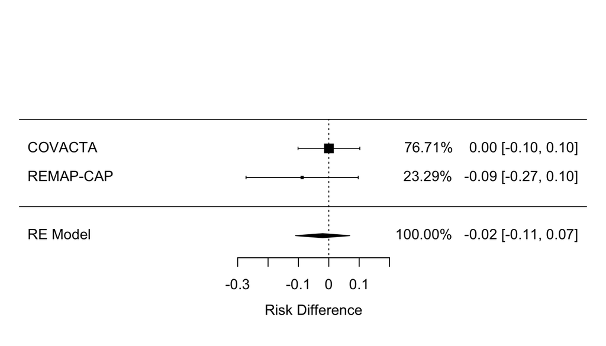

```r
priors_100_not_cortico_data_death =
  d %>%
  # Remove rows using different weights on REMAP-CAP
  filter(str_detect(trial, "%", negate = TRUE)) %>%
  filter(
    trial != "RECOVERY", # Not RECOVERY
    corticosteroids == 0 # Not using corticosteroids
  )

priors_100_not_cortico_death =
  rma(
    # Outcome
    measure = "RD", # risk difference

    # Tocilizumab group
    ai = events_toci,
    n1i = total_toci,

    # Control group
    ci = events_control,
    n2i = total_control,

    data = priors_100_not_cortico_data_death %>% filter(outcome == "mortality"),

    slab = paste(trial),
    method = "REML"
  )

forest(priors_100_not_cortico_death,
       showweights = T,
       refline     = 0)
```

```r
## Save objects with rma() outputs to show forest plot in other files

save(priors_100_not_cortico_death,

     file = here("final_analyses", "output", "data",
                 "priors_100_not_cortico_death.RData"))
```

```r
### Generate posterior beta distributions using a noninformative beta(1,1) prior

set.seed = 123 # set seed for reproducibility (rbeta() function)

# Here I use the noninformative_posterior() in which you can find in the
# following path:
# here("final_analyses", "script", "functions", "noninformative_posterior.R")

noninformative_recovery_not_cortico_death = noninformative_posterior(
  recovery_not_cortico_data, # data
  "mortality" # outcome
)
```

```r
# Save objects with posterior distributions using non-informative priors

# save(noninformative_recovery_not_cortico_death,
#
#    file = here("final_analyses", "output", "data",
#                "noninformative_recovery_not_cortico_death.RData"))
```

```r
multiple_priors_100_not_cortico_death %>% flextable() %>% autofit()
```

| type | data.mean | data.sd | prior.mean | prior.sd | post.mean | post.sd |
| --- | --- | --- | --- | --- | --- | --- |
| evidence-based | 0.0433067 | 0.03576411 | -0.02014643 | 0.04548108 | 0.019062138 | 0.02811327 |
| skeptical | 0.0433067 | 0.03576411 | 0.00000000 | 0.04548108 | 0.026759809 | 0.02811327 |
| optimistic | 0.0433067 | 0.03576411 | -0.05000000 | 0.04548108 | 0.007655504 | 0.02811327 |
| pessimistic | 0.0433067 | 0.03576411 | 0.05000000 | 0.04548108 | 0.045864114 | 0.02811327 |

Compiling all posteriors

```r
### Compile noninformative prior + other priors into a tibble for summary plot

all_posteriors_100_not_cortico_death = tibble_all_posteriors(

  # Output from noninformative_posterior()
  noninformative_recovery_not_cortico_death,

  # Output from normal_approximation_multiple_priors()
  multiple_priors_100_not_cortico_death
)
```

Example of one output with all the posteriors

```r
head(all_posteriors_100_not_cortico_death)%>% flextable() %>% autofit()
```

| Non-informative | Evidence-based | Skeptical | Optimistic | Pessimistic |
| --- | --- | --- | --- | --- |
| 0.065514107 | 0.011365132 | 0.03573947 | 0.06382626 | 0.06087961 |
| -0.004609744 | 0.042409752 | 0.05297425 | 0.01054478 | -0.01314056 |
| 0.034169622 | 0.002514844 | 0.03424510 | -0.02808433 | 0.08220239 |
| 0.080582386 | -0.013634332 | 0.01668349 | -0.02553398 | 0.03409913 |
| -0.004665282 | 0.002981586 | 0.07879535 | -0.01266121 | 0.03815647 |
| 0.075977764 | -0.037068197 | 0.01556003 | -0.04647632 | 0.04844005 |

```r
## Save objects with mean + SD of multiple priors along with
## RECOVERY data and posterior distributions

# save(multiple_priors_100_not_cortico_death,
#
#      file = here("final_analyses", "output", "data",
#                   "multiple_priors_100_not_cortico_death.RData"))
```

```r
## Save objects with all posteriors

# save(all_posteriors_100_not_cortico_death,
#
#      file = here("final_analyses", "output", "data",
#                  "all_posteriors_100_not_cortico_death.RData"))
```

### Using REMAP-CAP with 75% weight

#### Using corticosteroids

Let’s start the data wrangling

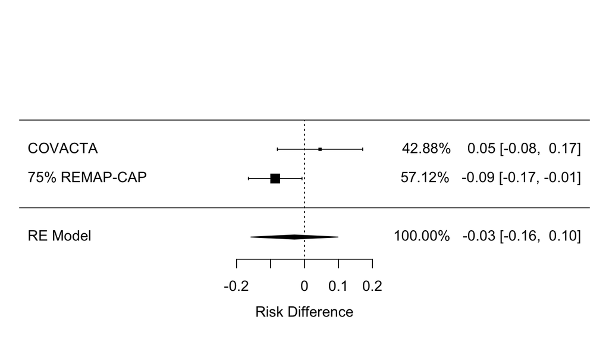

```r
priors_75_using_cortico_data_death =
  d %>%
  filter(
    trial %nin% c("RECOVERY", # Not RECOVERY /// %nin% from the {Hmisc} package
    "REMAP-CAP", # Not 100% weight
    "50% REMAP-CAP"), # Not 50%
    corticosteroids == 1 # Using corticosteroids
  )

priors_75_using_cortico_death =
  rma(
    # Outcome
    measure = "RD", # risk difference

    # Tocilizumab group
    ai = events_toci,
    n1i = total_toci,

    # Control group
    ci = events_control,
    n2i = total_control,

    data = priors_75_using_cortico_data_death %>% filter(outcome == "mortality"),

    slab = paste(trial),
    method = "REML"
  )

forest(priors_75_using_cortico_death,
       showweights = T,
       refline     = 0)
```

```r
## Save objects with rma() outputs to show forest plot in other files

# save(priors_75_using_cortico_death,
#
#      file = here("final_analyses", "output", "data",
#                  "priors_75_using_cortico_death.RData"))
```

```r
### Generate posterior beta distributions using a noninformative beta(1,1) prior

set.seed = 123 # set seed for reproducibility (rbeta() function)

# Here I use the noninformative_posterior() in which you can find in the
# following path:
# here("final_analyses", "script", "functions", "noninformative_posterior.R")

noninformative_recovery_using_cortico_death = noninformative_posterior(
  recovery_using_cortico_data, # data
  "mortality" # outcome
)
```

```r
multiple_priors_75_using_cortico_death %>% flextable() %>% autofit()
```

| type | data.mean | data.sd | prior.mean | prior.sd | post.mean | post.sd |
| --- | --- | --- | --- | --- | --- | --- |
| evidence-based | -0.05897105 | 0.01598291 | -0.02966592 | 0.06533356 | -0.05731627 | 0.0155251 |
| skeptical | -0.05897105 | 0.01598291 | 0.00000000 | 0.06533356 | -0.05564112 | 0.0155251 |
| optimistic | -0.05897105 | 0.01598291 | -0.05000000 | 0.06533356 | -0.05846448 | 0.0155251 |
| pessimistic | -0.05897105 | 0.01598291 | 0.05000000 | 0.06533356 | -0.05281776 | 0.0155251 |

Compiling all posteriors

```r
### Compile noninformative prior + other priors into a tibble for summary plot

all_posteriors_75_using_cortico_death = tibble_all_posteriors(

  # Output from noninformative_posterior()
  noninformative_recovery_using_cortico_death,

  # Output from normal_approximation_multiple_priors()
  multiple_priors_75_using_cortico_death
)
```

Example of one output with all the posteriors

```r
head(all_posteriors_75_using_cortico_death)%>% flextable() %>% autofit()
```

| Non-informative | Evidence-based | Skeptical | Optimistic | Pessimistic |
| --- | --- | --- | --- | --- |
| -0.04564066 | -0.05140723 | -0.04823600 | -0.07522446 | -0.05465524 |
| -0.07714830 | -0.05540845 | -0.07347607 | -0.06169734 | -0.04651982 |
| -0.08401693 | -0.06972585 | -0.04538714 | -0.05653808 | -0.06224822 |
| -0.07716286 | -0.05665371 | -0.05829778 | -0.04246188 | -0.05175814 |
| -0.07444412 | -0.05934066 | -0.05468635 | -0.04531312 | -0.03789797 |
| -0.06960032 | -0.04949642 | -0.06218995 | -0.08658500 | -0.05011040 |

```r
## Save objects with mean + SD of multiple priors along with
## RECOVERY data and posterior distributions

# save(multiple_priors_75_using_cortico_death,
#
#      file = here("final_analyses", "output", "data",
#                   "multiple_priors_75_using_cortico_death.RData"))
```

```r
## Save objects with all posteriors

# save(all_posteriors_75_using_cortico_death,
#
#      file = here("final_analyses", "output", "data",
#                  "all_posteriors_75_using_cortico_death.RData"))
```

#### Not using corticosteroids

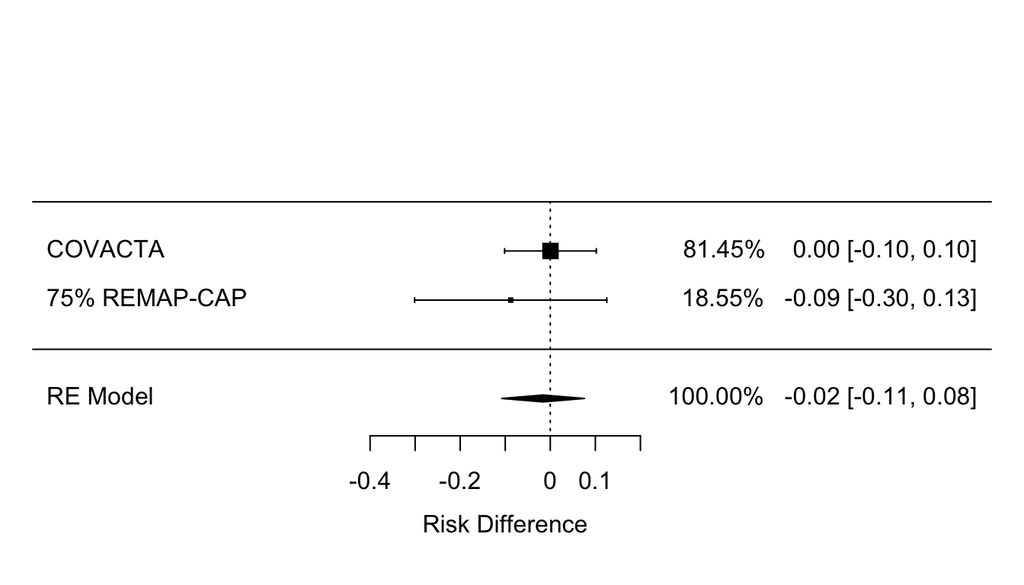

```r
priors_75_not_cortico_data_death =
  d %>%
  filter(
    trial %nin% c("RECOVERY", # Not RECOVERY /// %nin% from the {Hmisc} package
    "REMAP-CAP", # Not 100% weight
    "50% REMAP-CAP"), # Not 50%
    corticosteroids == 0 # Not using corticosteroids
  )

priors_75_not_cortico_death =
  rma(
    # Outcome
    measure = "RD", # risk difference

    # Tocilizumab group
    ai = events_toci,
    n1i = total_toci,

    # Control group
    ci = events_control,
    n2i = total_control,

    data = priors_75_not_cortico_data_death %>% filter(outcome == "mortality"),

    slab = paste(trial),
    method = "REML"
  )

forest(priors_75_not_cortico_death,
       showweights = T,
       refline     = 0)
```

```r
## Save objects with rma() outputs to show forest plot in other files

# save(priors_75_not_cortico_death,
#
#      file = here("final_analyses", "output", "data",
#                  "priors_75_not_cortico_death.RData"))
#
```

```r
### Generate posterior beta distributions using a noninformative beta(1,1) prior

set.seed = 123 # set seed for reproducibility (rbeta() function)

# Here I use the noninformative_posterior() in which you can find in the
# following path:
# here("final_analyses", "script", "functions", "noninformative_posterior.R")

noninformative_recovery_not_cortico_death = noninformative_posterior(
  recovery_not_cortico_data, # data
  "mortality" # outcome
)
```

```r
multiple_priors_75_not_cortico_death %>% flextable() %>% autofit()
```

| type | data.mean | data.sd | prior.mean | prior.sd | post.mean | post.sd |
| --- | --- | --- | --- | --- | --- | --- |
| evidence-based | 0.0433067 | 0.03576411 | -0.01596081 | 0.04686612 | 0.021494797 | 0.02843135 |
| skeptical | 0.0433067 | 0.03576411 | 0.00000000 | 0.04686612 | 0.027368766 | 0.02843135 |
| optimistic | 0.0433067 | 0.03576411 | -0.05000000 | 0.04686612 | 0.008967535 | 0.02843135 |
| pessimistic | 0.0433067 | 0.03576411 | 0.05000000 | 0.04686612 | 0.045769997 | 0.02843135 |

Compiling all posteriors

```r
### Compile noninformative prior + other priors into a tibble for summary plot

all_posteriors_75_not_cortico_death = tibble_all_posteriors(

  # Output from noninformative_posterior()
  noninformative_recovery_not_cortico_death,

  # Output from normal_approximation_multiple_priors()
  multiple_priors_75_not_cortico_death
)
```

Example of one output with all the posteriors

```r
head(all_posteriors_75_not_cortico_death)%>% flextable() %>% autofit()
```

| Non-informative | Evidence-based | Skeptical | Optimistic | Pessimistic |
| --- | --- | --- | --- | --- |
| 0.073178070 | 0.02715495 | 0.027650771 | 0.013802523 | 0.07705478 |
| 0.018739711 | 0.04993664 | 0.006889297 | -0.018037614 | 0.00775528 |
| 0.057463184 | 0.04422373 | 0.043112068 | -0.032773080 | 0.05688197 |
| 0.009681026 | 0.05035313 | -0.005580424 | 0.008525031 | 0.03375386 |
| 0.045986752 | 0.03150938 | 0.030026660 | 0.001573803 | 0.05493865 |
| 0.008992795 | 0.04018637 | 0.044759546 | 0.038369441 | 0.02151563 |

```r
## Save objects with mean + SD of multiple priors along with
## RECOVERY data and posterior distributions

# save(multiple_priors_75_not_cortico_death,
#
#      file = here("final_analyses", "output", "data",
#                   "multiple_priors_75_not_cortico_death.RData"))
```

```r
## Save objects with all posteriors

# save(all_posteriors_75_not_cortico_death,
#
#      file = here("final_analyses", "output", "data",
#                  "all_posteriors_75_not_cortico_death.RData"))
```

### Using REMAP-CAP with 50% weight

#### Using corticosteroids

Let’s start the data wrangling

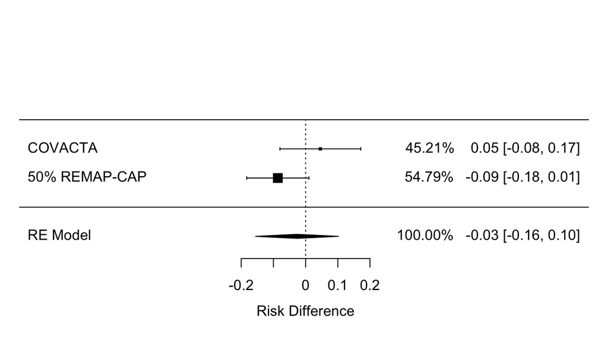

```r
priors_50_using_cortico_data_death =
  d %>%
  filter(
    trial %nin% c("RECOVERY", # Not RECOVERY /// %nin% from the {Hmisc} package
    "REMAP-CAP", # Not 100% weight
    "75% REMAP-CAP"), # Not 75%
    corticosteroids == 1 # Using corticosteroids
  )

priors_50_using_cortico_death =
  rma(
    # Outcome
    measure = "RD", # risk difference

    # Tocilizumab group
    ai = events_toci,
    n1i = total_toci,

    # Control group
    ci = events_control,
    n2i = total_control,

    data = priors_50_using_cortico_data_death %>% filter(outcome == "mortality"),

    slab = paste(trial),
    method = "REML"
  )

forest(priors_50_using_cortico_death,
       showweights = T,
       refline     = 0)
```

```r
## Save objects with rma() outputs to show forest plot in other files

# save(priors_50_using_cortico_death,
#
#      file = here("final_analyses", "output", "data",
#                  "priors_50_using_cortico_death.RData"))
```

```r
### Generate posterior beta distributions using a noninformative beta(1,1) prior

set.seed = 123 # set seed for reproducibility (rbeta() function)

# Here I use the noninformative_posterior() in which you can find in the
# following path:
# here("final_analyses", "script", "functions", "noninformative_posterior.R")

noninformative_recovery_using_cortico_death = noninformative_posterior(
  recovery_using_cortico_data, # data
  "mortality" # outcome
)
```

```r
multiple_priors_50_using_cortico_death %>% flextable() %>% autofit()
```

| type | data.mean | data.sd | prior.mean | prior.sd | post.mean | post.sd |
| --- | --- | --- | --- | --- | --- | --- |
| evidence-based | -0.05897105 | 0.01598291 | -0.02659633 | 0.06570191 | -0.05716224 | 0.01553001 |
| skeptical | -0.05897105 | 0.01598291 | 0.00000000 | 0.06570191 | -0.05567628 | 0.01553001 |
| optimistic | -0.05897105 | 0.01598291 | -0.05000000 | 0.06570191 | -0.05846983 | 0.01553001 |
| pessimistic | -0.05897105 | 0.01598291 | 0.05000000 | 0.06570191 | -0.05288272 | 0.01553001 |

Compiling all posteriors

```r
### Compile noninformative prior + other priors into a tibble for summary plot

all_posteriors_50_using_cortico_death = tibble_all_posteriors(

  # Output from noninformative_posterior()
  noninformative_recovery_using_cortico_death,

  # Output from normal_approximation_multiple_priors()
  multiple_priors_50_using_cortico_death
)
```

Example of one output with all the posteriors

```r
head(all_posteriors_50_using_cortico_death)%>% flextable() %>% autofit()
```

| Non-informative | Evidence-based | Skeptical | Optimistic | Pessimistic |
| --- | --- | --- | --- | --- |
| -0.03305800 | -0.07065188 | -0.04083423 | -0.02944621 | -0.05076120 |
| -0.06308708 | -0.07706948 | -0.05982401 | -0.06528471 | -0.05431934 |
| -0.06728022 | -0.07172630 | -0.04764772 | -0.08578409 | -0.05127059 |
| -0.02912665 | -0.05932668 | -0.02815017 | -0.06189252 | -0.08591881 |
| -0.07103651 | -0.05981518 | -0.07808734 | -0.06869881 | -0.07259623 |
| -0.03641777 | -0.03218152 | -0.05405667 | -0.05211435 | -0.03578560 |

```r
## Save objects with mean + SD of multiple priors along with
## RECOVERY data and posterior distributions

# save(multiple_priors_50_using_cortico_death,
#
#      file = here("final_analyses", "output", "data",
#                   "multiple_priors_50_using_cortico_death.RData"))
```

```r
## Save objects with all posteriors

# save(all_posteriors_50_using_cortico_death,
#
#      file = here("final_analyses", "output", "data",
#                  "all_posteriors_50_using_cortico_death.RData"))
```

#### Not using corticosteroids

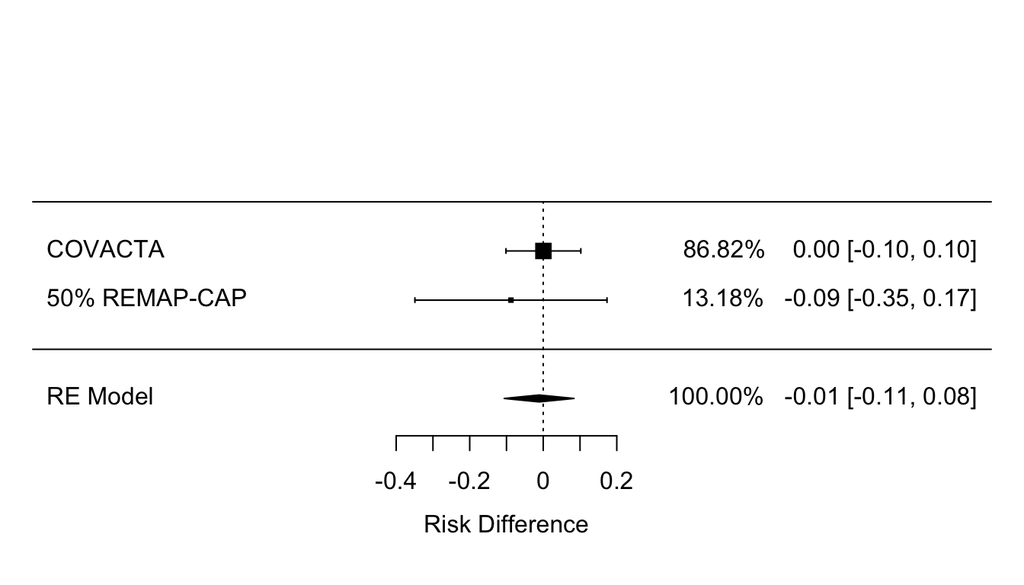

```r
priors_50_not_cortico_data_death =
  d %>%
  filter(
    trial %nin% c("RECOVERY", # Not RECOVERY /// %nin% from the {Hmisc} package
    "REMAP-CAP", # Not 100% weight
    "75% REMAP-CAP"), # Not 75%
    corticosteroids == 0 # Not using corticosteroids
  )

priors_50_not_cortico_death =
  rma(
    # Outcome
    measure = "RD", # risk difference

    # Tocilizumab group
    ai = events_toci,
    n1i = total_toci,

    # Control group
    ci = events_control,
    n2i = total_control,

    data = priors_50_not_cortico_data_death %>% filter(outcome == "mortality"),

    slab = paste(trial),
    method = "REML"
  )

forest(priors_50_not_cortico_death,
       showweights = T,
       refline     = 0)
```

```r
## Save objects with rma() outputs to show forest plot in other files

# save(priors_50_not_cortico_death,
#
#      file = here("final_analyses", "output", "data",
#                  "priors_50_not_cortico_death.RData"))
#
```

```r
### Generate posterior beta distributions using a noninformative beta(1,1) prior

set.seed = 123 # set seed for reproducibility (rbeta() function)

# Here I use the noninformative_posterior() in which you can find in the
# following path:
# here("final_analyses", "script", "functions", "noninformative_posterior.R")

noninformative_recovery_not_cortico_death = noninformative_posterior(
  recovery_not_cortico_data, # data
  "mortality" # outcome
)
```

```r
multiple_priors_50_not_cortico_death %>% flextable() %>% autofit()
```

| type | data.mean | data.sd | prior.mean | prior.sd | post.mean | post.sd |
| --- | --- | --- | --- | --- | --- | --- |
| evidence-based | 0.0433067 | 0.03576411 | -0.01122344 | 0.04838594 | 0.02404075 | 0.02876047 |
| skeptical | 0.0433067 | 0.03576411 | 0.00000000 | 0.04838594 | 0.02800608 | 0.02876047 |
| optimistic | 0.0433067 | 0.03576411 | -0.05000000 | 0.04838594 | 0.01034067 | 0.02876047 |
| pessimistic | 0.0433067 | 0.03576411 | 0.05000000 | 0.04838594 | 0.04567150 | 0.02876047 |

Compiling all posteriors

```r
### Compile noninformative prior + other priors into a tibble for summary plot

all_posteriors_50_not_cortico_death = tibble_all_posteriors(

  # Output from noninformative_posterior()
  noninformative_recovery_not_cortico_death,

  # Output from normal_approximation_multiple_priors()
  multiple_priors_50_not_cortico_death
)
```

Example of one output with all the posteriors

```r
head(all_posteriors_50_not_cortico_death)%>% flextable() %>% autofit()
```

| Non-informative | Evidence-based | Skeptical | Optimistic | Pessimistic |
| --- | --- | --- | --- | --- |
| -0.006323625 | 0.057822859 | 0.012132858 | 0.0052610273 | 0.07218549 |
| 0.009210738 | -0.059382228 | 0.014060590 | -0.0005736034 | 0.04295637 |
| 0.037706739 | 0.024516521 | 0.009339928 | -0.0206042108 | 0.10244322 |
| 0.032002006 | 0.025889869 | 0.033865041 | 0.0071867205 | 0.09728327 |
| 0.131782874 | -0.018101209 | 0.059077556 | 0.0757143178 | 0.05729055 |
| 0.023939770 | 0.009094971 | 0.026876623 | 0.0057737367 | 0.01704574 |

```r
## Save objects with mean + SD of multiple priors along with
## RECOVERY data and posterior distributions

# save(multiple_priors_50_not_cortico_death,
#
#      file = here("final_analyses", "output", "data",
#                   "multiple_priors_50_not_cortico_death.RData"))
```

```r
## Save objects with all posteriors

# save(all_posteriors_50_not_cortico_death,
#
#      file = here("final_analyses", "output", "data",
#                  "all_posteriors_50_not_cortico_death.RData"))
```

### Using REMAP-CAP with 0% weight

#### Using corticosteroids

Let’s start the data wrangling

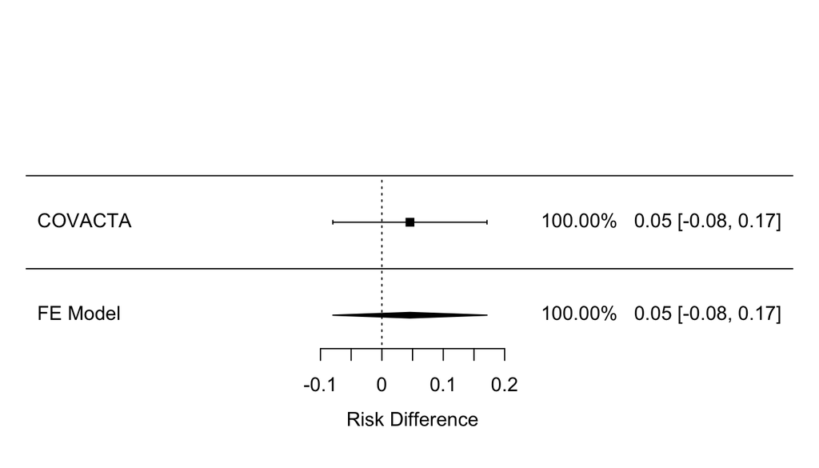

```r
priors_0_using_cortico_data_death =
  d %>%
  filter(
    trial %nin% c("RECOVERY", # Not RECOVERY /// %nin% from the {Hmisc} package
    "REMAP-CAP", # Not 100% weight
    "75% REMAP-CAP", # Not 75%
    "50% REMAP-CAP"), # Not 75%
    corticosteroids == 1 # Using corticosteroids
  )

priors_0_using_cortico_death =
  rma(
    # Outcome
    measure = "RD", # risk difference

    # Tocilizumab group
    ai = events_toci,
    n1i = total_toci,

    # Control group
    ci = events_control,
    n2i = total_control,

    data = priors_0_using_cortico_data_death %>% filter(outcome == "mortality"),

    slab = paste(trial),
    method = "REML"
  )

forest(priors_0_using_cortico_death,
       showweights = T,
       refline     = 0)
```

```r
## Save objects with rma() outputs to show forest plot in other files

# save(priors_0_using_cortico_death,
#
#      file = here("final_analyses", "output", "data",
#                  "priors_0_using_cortico_death.RData"))
```

```r
### Generate posterior beta distributions using a noninformative beta(1,1) prior

set.seed = 123 # set seed for reproducibility (rbeta() function)

# Here I use the noninformative_posterior() in which you can find in the
# following path:
# here("final_analyses", "script", "functions", "noninformative_posterior.R")

noninformative_recovery_using_cortico_death = noninformative_posterior(
  recovery_using_cortico_data, # data
  "mortality" # outcome
)
```

```r
multiple_priors_0_using_cortico_death %>% flextable() %>% autofit()
```

| type | data.mean | data.sd | prior.mean | prior.sd | post.mean | post.sd |
| --- | --- | --- | --- | --- | --- | --- |
| evidence-based | -0.05897105 | 0.01598291 | 0.0457368 | 0.06404588 | -0.05283243 | 0.01550733 |
| skeptical | -0.05897105 | 0.01598291 | 0.0000000 | 0.06404588 | -0.05551380 | 0.01550733 |
| optimistic | -0.05897105 | 0.01598291 | -0.0500000 | 0.06404588 | -0.05844511 | 0.01550733 |
| pessimistic | -0.05897105 | 0.01598291 | 0.0500000 | 0.06404588 | -0.05258249 | 0.01550733 |

Compiling all posteriors

```r
### Compile noninformative prior + other priors into a tibble for summary plot

all_posteriors_0_using_cortico_death = tibble_all_posteriors(

  # Output from noninformative_posterior()
  noninformative_recovery_using_cortico_death,

  # Output from normal_approximation_multiple_priors()
  multiple_priors_0_using_cortico_death
)
```

Example of one output with all the posteriors

```r
head(all_posteriors_0_using_cortico_death)%>% flextable() %>% autofit()
```

| Non-informative | Evidence-based | Skeptical | Optimistic | Pessimistic |
| --- | --- | --- | --- | --- |
| -0.05975850 | -0.03998920 | -0.04385652 | -0.04808137 | -0.05759904 |
| -0.04115330 | -0.04133189 | -0.05139145 | -0.07725379 | -0.04067967 |
| -0.03708852 | -0.04018350 | -0.02755136 | -0.05482192 | -0.06136987 |
| -0.05576815 | -0.05163780 | -0.04279556 | -0.05234054 | -0.06979845 |
| -0.05442402 | -0.08312542 | -0.04437544 | -0.05626622 | -0.07258595 |
| -0.04639422 | -0.05761058 | -0.04058777 | -0.07110734 | -0.06865344 |

```r
## Save objects with mean + SD of multiple priors along with
## RECOVERY data and posterior distributions

# save(multiple_priors_0_using_cortico_death,
#
#      file = here("final_analyses", "output", "data",
#                   "multiple_priors_0_using_cortico_death.RData"))
```

```r
## Save objects with all posteriors

# save(all_posteriors_0_using_cortico_death,
#
#      file = here("final_analyses", "output", "data",
#                  "all_posteriors_0_using_cortico_death.RData"))
```

#### Not using corticosteroids

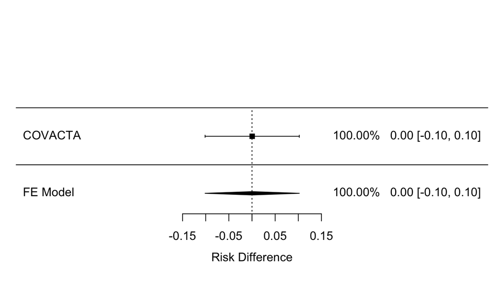

```r
priors_0_not_cortico_data_death =
  d %>%
  filter(
    trial %nin% c("RECOVERY", # Not RECOVERY /// %nin% from the {Hmisc} package
    "REMAP-CAP", # Not 100% weight
    "75% REMAP-CAP",
    "50% REMAP-CAP"), # Not 75%
    corticosteroids == 0 # Not using corticosteroids
  )

priors_0_not_cortico_death =
  rma(
    # Outcome
    measure = "RD", # risk difference

    # Tocilizumab group
    ai = events_toci,
    n1i = total_toci,

    # Control group
    ci = events_control,
    n2i = total_control,

    data = priors_0_not_cortico_data_death %>% filter(outcome == "mortality"),

    slab = paste(trial),
    method = "REML"
  )

forest(priors_0_not_cortico_death,
       showweights = T,
       refline     = 0)
```

```r
## Save objects with rma() outputs to show forest plot in other files

# save(priors_0_not_cortico_death,
#
#      file = here("final_analyses", "output", "data",
#                  "priors_0_not_cortico_death.RData"))
#
```

```r
### Generate posterior beta distributions using a noninformative beta(1,1) prior

set.seed = 123 # set seed for reproducibility (rbeta() function)

# Here I use the noninformative_posterior() in which you can find in the
# following path:
# here("final_analyses", "script", "functions", "noninformative_posterior.R")

noninformative_recovery_not_cortico_death = noninformative_posterior(
  recovery_not_cortico_data, # data
  "mortality" # outcome
)
```

```r
multiple_priors_0_not_cortico_death %>% flextable() %>% autofit()
```

| type | data.mean | data.sd | prior.mean | prior.sd | post.mean | post.sd |
| --- | --- | --- | --- | --- | --- | --- |
| evidence-based | 0.0433067 | 0.03576411 | 0.0004091653 | 0.05192948 | 0.02950575 | 0.02945454 |
| skeptical | 0.0433067 | 0.03576411 | 0.0000000000 | 0.05192948 | 0.02937411 | 0.02945454 |
| optimistic | 0.0433067 | 0.03576411 | -0.0500000000 | 0.05192948 | 0.01328817 | 0.02945454 |
| pessimistic | 0.0433067 | 0.03576411 | 0.0500000000 | 0.05192948 | 0.04546006 | 0.02945454 |

Compiling all posteriors

```r
### Compile noninformative prior + other priors into a tibble for summary plot

all_posteriors_0_not_cortico_death = tibble_all_posteriors(

  # Output from noninformative_posterior()
  noninformative_recovery_not_cortico_death,

  # Output from normal_approximation_multiple_priors()
  multiple_priors_0_not_cortico_death
)
```

Example of one output with all the posteriors

```r
head(all_posteriors_0_not_cortico_death)%>% flextable() %>% autofit()
```

| Non-informative | Evidence-based | Skeptical | Optimistic | Pessimistic |
| --- | --- | --- | --- | --- |
| 0.01501331 | 0.04530984 | 0.00113465 | -0.003785487 | 0.06133907 |
| 0.14448617 | 0.02417743 | 0.05250000 | -0.011625258 | 0.04302451 |
| 0.02454986 | 0.04462365 | 0.04643631 | -0.009682480 | 0.03450920 |
| 0.05488793 | 0.03798950 | 0.01801467 | -0.001932629 | 0.04516414 |
| 0.10073300 | 0.05539610 | 0.01618830 | -0.004109605 | 0.06712394 |
| -0.04101642 | 0.06055136 | 0.03966321 | -0.040215308 | 0.04614659 |

```r
## Save objects with mean + SD of multiple priors along with
## RECOVERY data and posterior distributions

# save(multiple_priors_0_not_cortico_death,
#
#      file = here("final_analyses", "output", "data",
#                   "multiple_priors_0_not_cortico_death.RData"))
```

```r
## Save objects with all posteriors

# save(all_posteriors_0_not_cortico_death,
#
#      file = here("final_analyses", "output", "data",
#                  "all_posteriors_0_not_cortico_death.RData"))
```

### Summary

#### Using corticosteroids

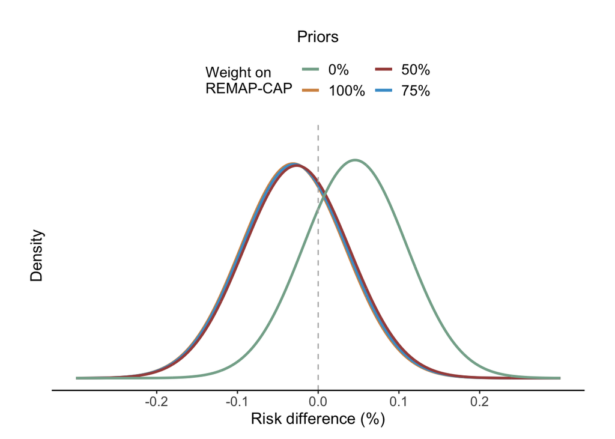

```r
pal = c("100%" = "#D49352",
        "75%" = "#479ED0",
        "50%" = "#A64E49",
        "0%" = "#85AD99")

plot_prior = ggplot(data = data.frame(x = c(-0.3, 0.3)), aes(x)) +

  stat_function(fun = dnorm, n = 1000,
                args = list(mean = priors_100_using_cortico_death$beta,
                            sd = priors_100_using_cortico_death$se),
                aes(colour = "100%"),
                linetype = 1, size = 1) +

  stat_function(fun = dnorm, n = 1000,
                args = list(mean = priors_75_using_cortico_death$beta,
                            sd = priors_75_using_cortico_death$se),
                aes(colour = "75%"),
                linetype = 1, size = 1) +

  stat_function(fun = dnorm, n = 1000,
                args = list(mean = priors_50_using_cortico_death$beta,
                            sd = priors_50_using_cortico_death$se),
                aes(colour = "50%"),
                linetype = 1, size = 1) +

  stat_function(fun = dnorm, n = 1000,
                args = list(mean = priors_0_using_cortico_death$beta,
                            sd = priors_0_using_cortico_death$se),
                aes(colour = "0%"),
                linetype = 1, size = 1) +

  geom_vline(xintercept = 0, color="grey70", linetype = 2) +

  scale_colour_manual("Weight on\nREMAP-CAP",values = pal) +   # legend

  # to split legend in two rows https://ggplot2.tidyverse.org/reference/guide_legend.html
  guides(col = guide_legend(nrow = 2)) +

  labs(title = "Priors", x="Risk difference (%)", y = "Density") +

  scale_x_continuous(breaks=seq(from = -0.2, to = 0.2, 0.1)) +
  scale_y_continuous(limits=c(0, 7)) +

  theme_classic() +
  theme(axis.line.y=element_blank(),
        axis.title = element_text(size = 13),
        axis.text.y=element_blank(),
        axis.text.x = element_text(size = 11),
        axis.ticks.y=element_blank(),
        plot.title = element_text(hjust = 0.5),
        legend.title = element_text(size = 12),
        legend.text = element_text(size = 12),
        legend.position = "top",
        plot.margin = margin(25,25,10,25)) +

  coord_cartesian(expand = T, clip = 'off')

plot_prior
```

## Hospital discharge outcome

**There is no data available from the RECAP-CAP trial.**

### Using corticosteroids

Let’s start the data wrangling

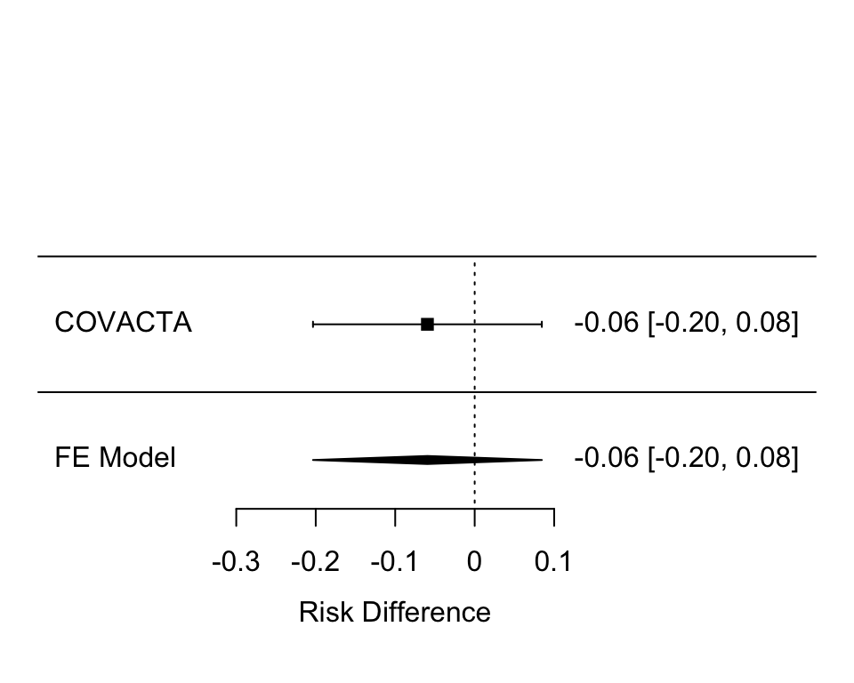

```r
priors_using_cortico_data_discharge =
  d %>%
  filter(
    trial != "RECOVERY", # Not RECOVERY
    corticosteroids == 1 # Using corticosteroids
  )

priors_using_cortico_discharge =
  rma(
    # Outcome
    measure = "RD", # risk difference

    # Tocilizumab group
    ai = events_toci,
    n1i = total_toci,

    # Control group
    ci = events_control,
    n2i = total_control,

    data = priors_using_cortico_data_discharge %>% filter(outcome == "discharge"),

    slab = paste(trial),
    method = "REML"
  )

forest(priors_using_cortico_discharge)
```

```r
## Save objects with rma() outputs to show forest plot in other files

# save(priors_using_cortico_discharge,
#
#      file = here("final_analyses", "output", "data",
#                  "priors_using_cortico_discharge.RData"))
```

```r
### Generate posterior beta distributions using a noninformative beta(1,1) prior

set.seed = 123 # set seed for reproducibility (rbeta() function)

# Here I use the noninformative_posterior() in which you can find in the
# following path:
# here("final_analyses", "script", "functions", "noninformative_posterior.R")

noninformative_recovery_using_cortico_discharge = noninformative_posterior(
  recovery_using_cortico_data, # data
  "discharge" # outcome
)
```

```r
# Save objects with posterior distributions using non-informative priors

# save(noninformative_recovery_using_cortico_discharge,
#
#    file = here("final_analyses", "output", "data",
#                "noninformative_recovery_using_cortico_discharge.RData"))
```

```r
multiple_priors_using_cortico_discharge %>% flextable() %>% autofit()
```

| type | data.mean | data.sd | prior.mean | prior.sd | post.mean | post.sd |
| --- | --- | --- | --- | --- | --- | --- |
| evidence-based | 0.08588582 | 0.01703198 | -0.05946979 | 0.07346161 | 0.07847098 | 0.01659188 |
| skeptical | 0.08588582 | 0.01703198 | 0.00000000 | 0.07346161 | 0.08150463 | 0.01659188 |
| optimistic | 0.08588582 | 0.01703198 | 0.05000000 | 0.07346161 | 0.08405522 | 0.01659188 |
| pessimistic | 0.08588582 | 0.01703198 | -0.05000000 | 0.07346161 | 0.07895405 | 0.01659188 |

Compiling all posteriors

```r
### Compile noninformative prior + other priors into a tibble for summary plot

all_posteriors_using_cortico_discharge = tibble_all_posteriors(

  # Output from noninformative_posterior()
  noninformative_recovery_using_cortico_discharge,

  # Output from normal_approximation_multiple_priors()
  multiple_priors_using_cortico_discharge
)
```

Example of one output with all the posteriors

```r
head(all_posteriors_using_cortico_discharge)%>% flextable() %>% autofit()
```

| Non-informative | Evidence-based | Skeptical | Optimistic | Pessimistic |
| --- | --- | --- | --- | --- |
| 0.05953866 | 0.07451684 | 0.08002219 | 0.06450416 | 0.09877872 |
| 0.08099027 | 0.07811076 | 0.06437342 | 0.09851102 | 0.10607985 |
| 0.07709347 | 0.06540143 | 0.08833107 | 0.07091905 | 0.09484447 |
| 0.07239958 | 0.05602190 | 0.08663071 | 0.10529712 | 0.05949313 |
| 0.10882185 | 0.08303598 | 0.10715151 | 0.09811328 | 0.07134519 |
| 0.10847186 | 0.07311046 | 0.09928249 | 0.08223833 | 0.06437410 |

```r
## Save objects with mean + SD of multiple priors along with
## RECOVERY data and posterior distributions

# save(multiple_priors_using_cortico_discharge,
#
#      file = here("final_analyses", "output", "data",
#                   "multiple_priors_using_cortico_discharge.RData"))
```

```r
## Save objects with all posteriors

# save(all_posteriors_using_cortico_discharge,
#
#      file = here("final_analyses", "output", "data",
#                  "all_posteriors_using_cortico_discharge.RData"))
```

### Not using corticosteroids

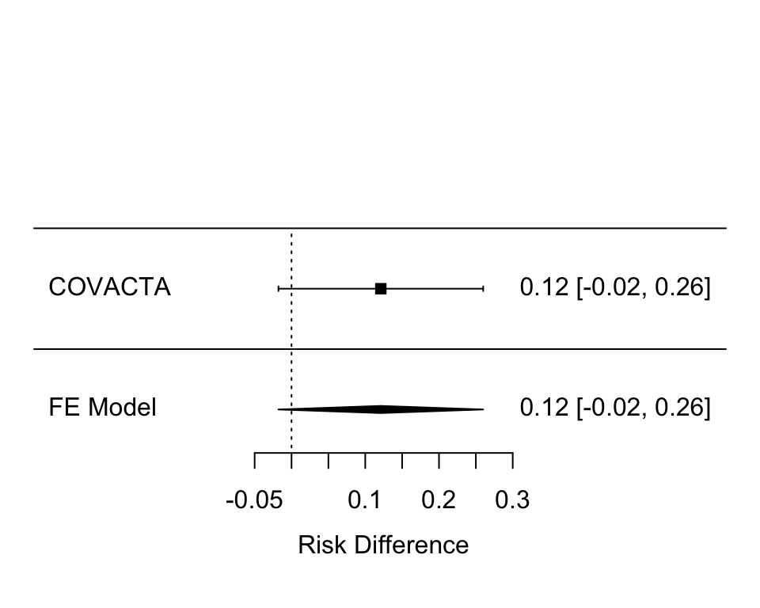

```r
priors_not_cortico_data_discharge =
  d %>%
  filter(
    trial != "RECOVERY",
    corticosteroids == 0 # Not using corticosteroids
  )

priors_not_cortico_discharge =
  rma(
    # Outcome
    measure = "RD", # risk difference

    # Tocilizumab group
    ai = events_toci,
    n1i = total_toci,

    # Control group
    ci = events_control,
    n2i = total_control,

    data = priors_not_cortico_data_discharge %>% filter(outcome == "discharge"),

    slab = paste(trial),
    method = "REML"
  )

forest(priors_not_cortico_discharge)
```

```r
## Save objects with rma() outputs to show forest plot in other files

# save(priors_not_cortico_discharge,
#
#      file = here("final_analyses", "output", "data",
#                  "priors_not_cortico_discharge.RData"))
```

```r
### Generate posterior beta distributions using a noninformative beta(1,1) prior

set.seed = 123 # set seed for reproducibility (rbeta() function)

# Here I use the noninformative_posterior() in which you can find in the
# following path:
# here("final_analyses", "script", "functions", "noninformative_posterior.R")

noninformative_recovery_not_cortico_discharge = noninformative_posterior(
  recovery_not_cortico_data, # data
  "discharge" # outcome
)
```

```r
# Save objects with posterior distributions using non-informative priors

# save(noninformative_recovery_not_cortico_discharge,
#
#    file = here("final_analyses", "output", "data",
#                "noninformative_recovery_not_cortico_discharge.RData"))
```

```r
multiple_priors_not_cortico_discharge %>% flextable() %>% autofit()
```

| type | data.mean | data.sd | prior.mean | prior.sd | post.mean | post.sd |
| --- | --- | --- | --- | --- | --- | --- |
| evidence-based | -0.003984155 | 0.03697104 | 0.1211129 | 0.07083598 | 0.022797491 | 0.03277547 |
| skeptical | -0.003984155 | 0.03697104 | 0.0000000 | 0.07083598 | -0.003131200 | 0.03277547 |
| optimistic | -0.003984155 | 0.03697104 | 0.0500000 | 0.07083598 | 0.007573145 | 0.03277547 |
| pessimistic | -0.003984155 | 0.03697104 | -0.0500000 | 0.07083598 | -0.013835544 | 0.03277547 |

Compiling all posteriors

```r
### Compile noninformative prior + other priors into a tibble for summary plot

all_posteriors_not_cortico_discharge = tibble_all_posteriors(

  # Output from noninformative_posterior()
  noninformative_recovery_not_cortico_discharge,

  # Output from normal_approximation_multiple_priors()
  multiple_priors_not_cortico_discharge
)
```

Example of one output with all the posteriors

```r
head(all_posteriors_not_cortico_discharge)%>% flextable() %>% autofit()
```

| Non-informative | Evidence-based | Skeptical | Optimistic | Pessimistic |
| --- | --- | --- | --- | --- |
| 0.02012427 | 0.038864748 | 0.0009693271 | -0.022244460 | -0.04109635 |
| -0.01357820 | -0.014683636 | -0.0567441166 | 0.044067712 | 0.03909684 |
| 0.03226543 | 0.018382446 | 0.0326589981 | 0.001271077 | 0.02379841 |
| -0.01567507 | 0.037918857 | -0.0384717393 | 0.008282995 | -0.06187782 |
| 0.02053322 | 0.007546741 | -0.0233943920 | 0.071221620 | -0.00259158 |
| 0.03004966 | 0.044047025 | 0.0329028858 | 0.018265386 | -0.03405022 |

```r
## Save objects with mean + SD of multiple priors along with
## RECOVERY data and posterior distributions

# save(multiple_priors_not_cortico_discharge,
#
#      file = here("final_analyses", "output", "data",
#                   "multiple_priors_not_cortico_discharge.RData"))
```

```r
## Save objects with all posteriors

# save(all_posteriors_not_cortico_discharge,
#
#      file = here("final_analyses", "output", "data",
#                  "all_posteriors_not_cortico_discharge.RData"))
```